# Stat184 Final Project - Sean Klavans

## Guiding Question:

Recently, there has been speculation that the way basketball is being played in the NBA is changing. Specifically, the game is becoming a lot more offense orientated in the sense that teams are scoring more points than in previous years and the game has sped up. I am going to be looking at in depth team data from 2014-2018 and historic player data from every NBA player that has ever played to try to determine if this is in fact a reality rather than a belief.

### Importing and Inspecting Datasets

```r
#Data Access
NBAData <- read.csv("nba.games.stats.csv") #Data Source 1
AllTime <- read.csv("Seasons_Stats.csv")   #Data Source 2

head(NBAData)  #DataAccess
nrow(NBAData)  #DataAccess
head(AllTime)
nrow(AllTime)
```

[output not shown]

### Libraries Used

```r
#Libraries
library(dplyr)
library(tidyverse)
library(lubridate)
```

### User Defined Function

```r
#Custom function to determine if a team is East or West
whichConf <- function(team){
  if (team %in% c("ATL", "BOS", "BRK" ,"CHI", "CHO",
                  "CLE", "DET", "IND", "MIA", "MIL",
                  "NYK", "ORL", "PHI", "TOR", "WAS")){
    return("East")
  }
  else {
    return("West")
  }
} #Wrangling 4 (Control flow with if-else statement)
```

### Data Visualization #1

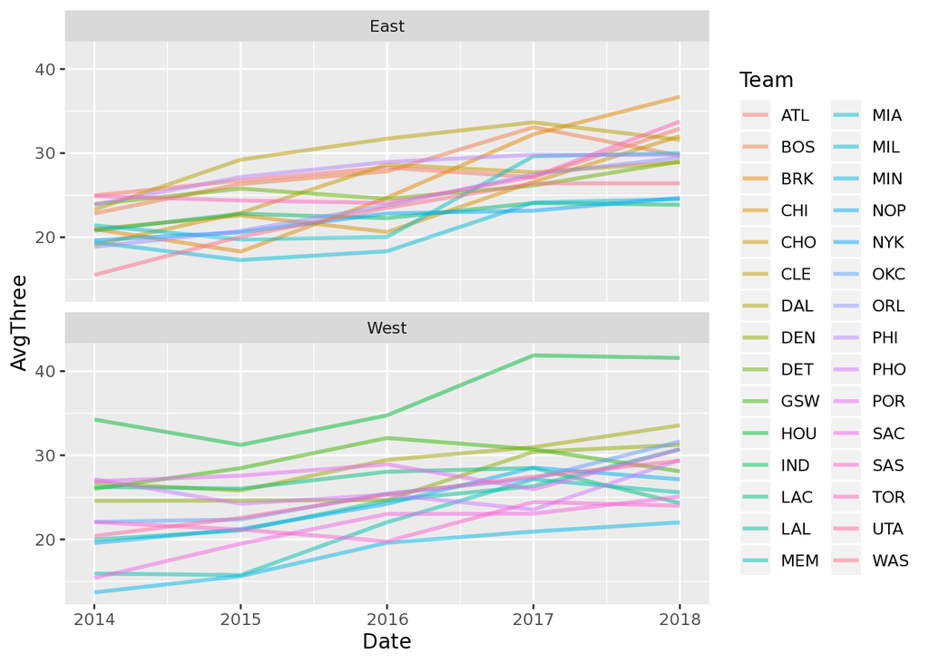

```r
#Visualizing Change of amounts of threes taken per year for each team
ModifiedNBA <-
NBAData %>%
  mutate(Date = year(lubridate::ymd(Date))) %>%  #Wrangling1
  group_by(Team,Date) %>%
  summarise(AvgThree = mean(X3PointShotsAttempted))  #Wrangling2

NewModified <-
  ModifiedNBA %>%
  mutate(Conf = whichConf(Team)) #Wrangling3 (Using my user defined function)

NewModified %>%
  ggplot(aes(x = Date, y = AvgThree, group = Team)) +
  geom_line(size = 1, alpha = 0.5, aes(color = Team)) +
  facet_wrap(~Conf, dir = "v") #Visualization 1 and 2
```

In the above plots, I am visualizing the average amount of threes taken for each team from the years 2014-2018 and faceting on which conference the teams are in for further detail. There are a few things to take away from the plots:

-It appears for both conferences, the average amount of threes taken per game has increased over this time period. This is relevant to my guiding question because taking more three pointers is indicative of a more offensive style of play.

-Although it is hard to discern which team is which due to the amount of teams on the plots (30), the overall trend of interest is still prominent.

### Data Visualization #2

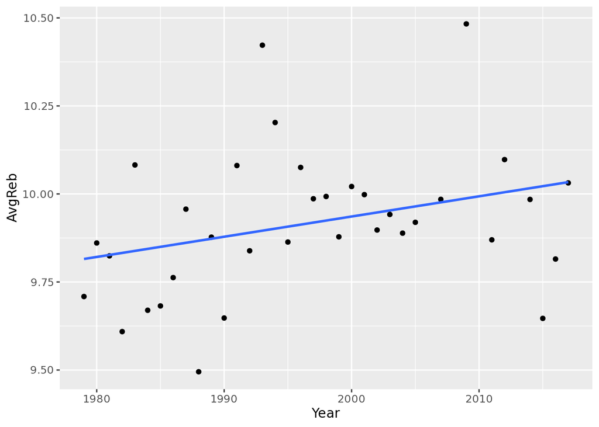

```r
#The three point line was not introduced until 1979, so I will only be looking at data starting from that point for my historic player data. This is considered by many to be a 'turning point' in NBA history, and the beginning of the three point era which is why I will only include this portion of the historical data in my analysis.
HistData <-
AllTime %>%
  filter(Year >= 1979)

HistRebounds <-
HistData %>%
  group_by(Year) %>%
  summarise(AvgReb = mean(TRB.))

HistRebounds %>%
  ggplot(aes(x = Year, y = AvgReb)) +
  geom_point(na.rm = TRUE) +
  geom_smooth(method = 'lm', se = FALSE, na.rm = TRUE) #Visualization3
```

### Linear Regression Analysis

```r
linearMod <- lm(FieldGoalsAttempted ~ TotalRebounds, data = NBAData) #DataWrangling5
summary(linearMod)
```

```
##
## Call:
## lm(formula = FieldGoalsAttempted ~ TotalRebounds, data = NBAData)
##
## Residuals:
##     Min      1Q  Median      3Q     Max
## -22.294  -4.349  -0.129   4.178  33.895
##
## Coefficients:
##               Estimate Std. Error t value Pr(>|t|)
## (Intercept)   64.34177    0.44659  144.07   <2e-16 ***
## TotalRebounds  0.47243    0.01015   46.54   <2e-16 ***
## ---
## Signif. codes:  0 '***' 0.001 '**' 0.01 '*' 0.05 '.' 0.1 ' ' 1
##
## Residual standard error: 6.455 on 9838 degrees of freedom
## Multiple R-squared:  0.1804, Adjusted R-squared:  0.1803
## F-statistic:  2166 on 1 and 9838 DF,  p-value: < 2.2e-16
```

In the above code chunk, I run a linear regression model to determine whether or not total rebounds has an impact on field goals attempted to back up the conclusions I made from the previous plot. According to the summary above, the significance test on whether or not total rebounds has an impact on field goals attempted shows that there is indeed a signficant relationship between the aforementiond variables.